# p1AP_uncorrupted

```python
import matplotlib.pyplot as plt
import numpy as np
from scipy.signal import periodogram
from scipy.fft import fft, ifft
from scipy.interpolate import make_lsq_spline, BSpline
from scipy.optimize import minimize
from scipy.optimize import curve_fit
import pandas as pd
```

```python
## Data extraction
filename = 'hst_oycar.dat'


data = []
header_skipped = False
with open(filename, 'r') as file:
    for line in file:
        line = line.strip()

        if not header_skipped:
            if '-' in line:
                header_skipped = True
            continue

        # Process data lines
        parts = line.split()
        if len(parts) >= 7:
            try:
                data.append({
                    'Spectrum Number': int(parts[0]),
                    'MJD': float(parts[1]),
                    'Relative Time': float(parts[2]),
                    'Dwell Time': float(parts[3]),
                    'Background Level': float(parts[4]),
                    'Optical Count Rate': float(parts[5]),
                    'Error Bar': float(parts[6])
                })
            except ValueError:
                # Handle cases where conversion fails
                continue
```

$ \huge \text{Report: Analysis of QPO's in a Binary System} $

In the following Jupyter Notebook we analyse the lightcruve of a binary system, including a white dwarf primary and a main sequence secondary star. We are interested in identifying the QPOs(Quasi-Periodic Oscillations) within the data and make predictions of there origins. We expect these to have period of the order of 10, around the kepler period of the white dwarf.

$ \large \text{Plot of the orginial lightcurve} $

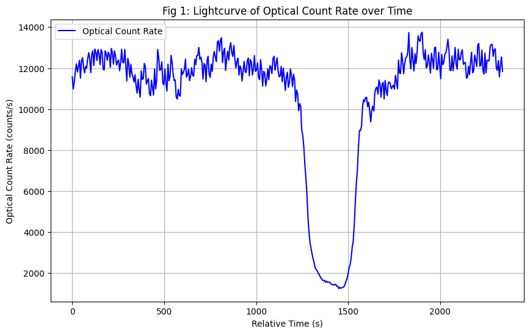

```python
t = np.array([entry['Relative Time'] for entry in data])
lightcurve = optical_count_rate = np.array([entry['Optical Count Rate'] for entry in data])

# Plot the lightcurve  of Optical_count_rate vs light curve
plt.figure(figsize=(10, 6))
plt.plot(t, optical_count_rate, color='b', label='Optical Count Rate')
plt.xlabel('Relative Time (s)')
plt.ylabel('Optical Count Rate (counts/s)')
plt.title('Fig 1: Lightcurve of Optical Count Rate over Time')
plt.legend()
plt.grid(True)
plt.show()
```

In this graph we plot the base data, Clearly there is an drop in count rate somewhere between 1250 and 1750 seconds, without further investigation it is not clearif there are higher frequency QPO's present in the data or just noise. In order to investigate this a loose fitting spline is fitting and subtract from the data to centre the data around the mean and to remove low frequency signals from the data. Note while there are some clear oscilattions in the data these are at frequencies too large to be QPO's

$ \large \text{Plots of the spline fit, residual lightcurve and the fourier transform} $

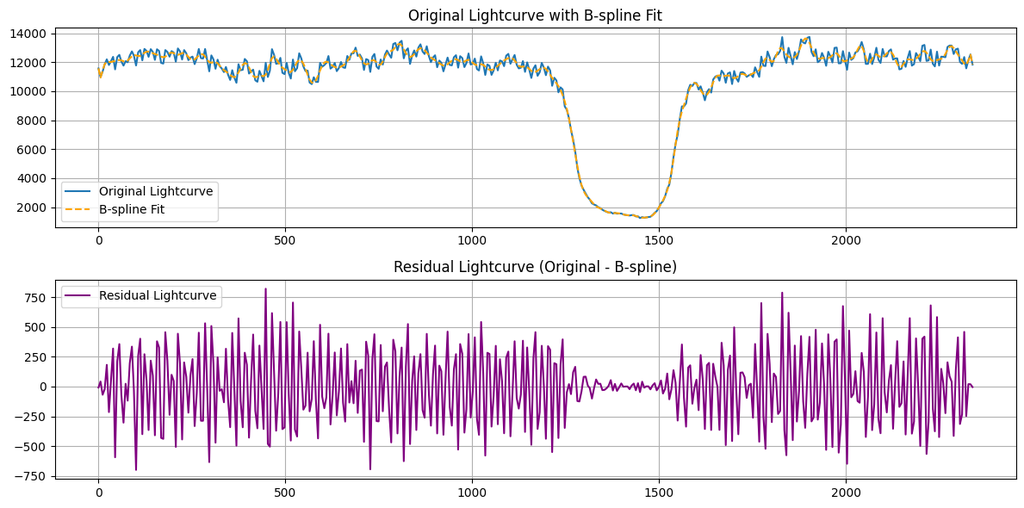

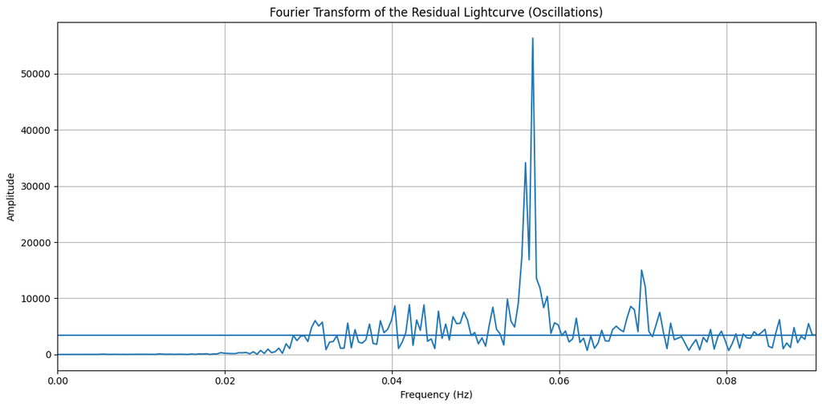

```python
## Fitting a loose fitting spline so about one knot every 3 points
num_knots = int(len(lightcurve)/3)
knots = np.linspace(t[0], t[-1], num_knots)
degree = 4 # Degree of the B-spline (cubic)
knots = np.concatenate(([t[0]] * degree, knots, [t[-1]] * degree))


## fitting the loose spline using scipy
spline = make_lsq_spline(t, lightcurve, knots, degree)


## Subtract the spline from the light_curve to get rid of high_pass frequencies
spline_fit = spline(t)
residual_lightcurve = lightcurve - spline_fit

## plot the inverse fourier transform to show that the lower frequencices have been eliminated
freq = np.fft.fftfreq(len(t), t[1] - t[0])
residual_fft = fft(residual_lightcurve)

## Plot of the initial light_curve and spline fit
plt.figure(figsize=(12, 6))
plt.subplot(2, 1, 1)
plt.title("Original Lightcurve with B-spline Fit")
plt.plot(t, lightcurve, label="Original Lightcurve")
plt.plot(t, spline_fit, label="B-spline Fit", linestyle="--", color="orange")
plt.legend()
plt.grid(True)

# Plot the residual lightcurve/ subtracted curve
plt.subplot(2, 1, 2)
plt.title("Residual Lightcurve (Original - B-spline)")
plt.plot(t, residual_lightcurve, color="purple", label="Residual Lightcurve")
plt.legend()
plt.grid(True)
plt.tight_layout()
plt.show()


# Plot the inverse fourier transform to show the elimination of higher frequencies
plt.figure(figsize=(12, 6))
plt.title("Fourier Transform of the Residual Lightcurve (Oscillations)")
plt.plot(freq,np.abs(residual_fft))
plt.xlim(0,freq.max())
plt.xlabel("Frequency (Hz)")
plt.ylabel("Amplitude")
plt.grid(True)
plt.tight_layout()
plt.show()
```

The graphs here show the loosley fitted spline( one knot per 3 data points this was chosen so the peaks at later frequencies show better) along with the residual lightcurve which we will analyse further. This is the curve from the original light curve minus the loose spline.

The residual lightcurve was fourier transformed to show the removal of low frequency modes from the signal and to show that there are clear peaks in the frequnecy domain these will likely correspond to QPO's which we will identify in a further next section.

It is also clear from our plot of the residual lightcurve that during the eclipse the amplitude of any oscillations significantly decrease, this indicates that QPO's maybe being obscured during the eclipse.

### Time and Frequency Analysis Parameters

Here I give run down of the important factors in determining the QPO's in the data, given a time array t , we can calculate key parameters for frequency analysis:

1. **Sampling Interval (Δt)**: The average time interval between samples(Note this data maybe all the same spacing)): $\Delta t = \frac{1}{N-1} \sum_{i=1}^{N-1} \left( t_{i+1} - t_i \right)$
2. **Sampling Frequency (f_sample)**: The inverse of the sampling interval, representing how often data points are recorded: $f_{\text{sample}} = \frac{1}{\Delta t}$
3. **Total Duration (T)**: The total time span of the data: $T = t_{N} - t_{1}$
4. **Nyquist Frequency (f_Nyquist)**: The Nyquist frequency is half the sampling frequency, setting the maximum detectable frequency without aliasing: $f_{\text{Nyquist}} = \frac{f_{\text{sample}}}{2}$
5. **Frequency Resolution (Δf)**: This is the smallest frequency interval that can be distinguished, determined by the length of the time series: $\Delta f = \frac{f_{\text{sample}}}{N}$
6. **Trial Frequencies (f_trial)**: The array of trial frequencies up to the Nyquist frequency is given by: $f_{\text{trial}} = \left[ 0, \Delta f, 2\Delta f, \ldots, f_{\text{Nyquist}} \right]$

Given these we can start to properly investigate the QPO's present

```python
time_intervals = np.diff(t)
delta_t = np.mean(time_intervals)
sample_freq = 1/delta_t

T = t[-1] - t[0]

nyquist_freq = sample_freq/2

# Calculate frequency resolution
Delta_f = sample_freq/len(t)

# Generate trial frequencies
# In order to plot better graphs low frequencies ignored
trial_frequencies = np.arange(0.0, nyquist_freq, Delta_f)
trial_frequencies_aliased = np.arange(0, nyquist_freq*2, Delta_f)
# Calculate total number of trial frequencies
N_f = len(trial_frequencies)

# Output results
print("Sampling Interval (Δt):", delta_t)
print("Sampling frequency (Hz):", sample_freq)
print("Total Duration (T):", T)
print("Nyquist Frequency (f_Nyquist):", nyquist_freq)
print("Frequency Resolution (Δf):", Delta_f)
print("Total Number of Trial Frequencies (N_f):", N_f)
```

```
Sampling Interval (Δt): 5.596590909090909
Sampling frequency (Hz): 0.17868020304568527
Total Duration (T): 2339.375
Nyquist Frequency (f_Nyquist): 0.08934010152284264
Frequency Resolution (Δf): 0.0004264443986770532
Total Number of Trial Frequencies (N_f): 210
```

As we are modelling Quasi-Periodic oscilations as periodic orbits, therefore the model will not fit the data very well and the chi_squared will be high therefore it is not appropriate to scale the error bars as that assumes the data should fit the model well. As such we will leave the error bars unscaled in the following sections.

$\displaystyle \large \text{Plots showing the } \chi^2 \text{ distribution for trial frequencies}$

```
Best Frequency: 0.0559 Hz
Best Fit Parameters (B, C, S): [ -4.13608347  67.21225978 155.15778871]
```

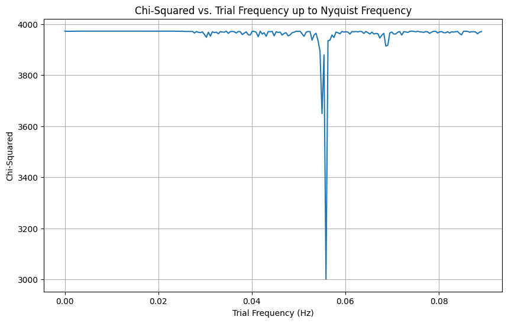

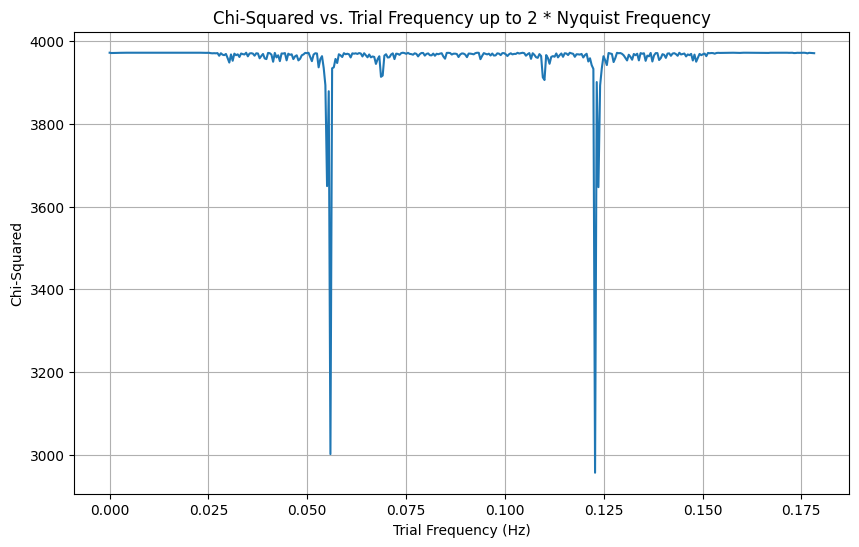

```python
### Define the 1-sigma error bars
sigma = np.array([entry['Error Bar'] for entry in data])

## Define the periodogram model
def model(t, B, C, S, f):
    return B + C * np.cos(2 * np.pi * f * t) + S * np.sin(2 * np.pi * f * t)

## Define chi_squared
def chi_squared(params, t, data, sigma, f):
    B, C, S = params
    model_values = model(t, B, C, S, f)
    return np.sum(((data - model_values) / sigma) ** 2)

def find_best_frequency(t, lightcurve, sigma, trial_frequencies, chi_squared_func):
    """
    Find the best frequency by minimizing the chi-squared value over a range of trial frequencies.

    Parameters:
    - t: Time array.
    - lightcurve: The light curve data
    - sigma: The uncertainty (error) associated with each data point in the light curve.
    - trial_frequencies: The frequencies to check.
    - chi_squared_func: The chi-squared function to minimize.

    Returns:
    - best_frequency: The frequency corresponding to the minimum chi-squared.
    - best_fit_params: The best-fit parameters corresponding to the minimum chi-squared.
    - chi_squared_values: An array of chi-squared values for each trial frequency.
    """

    chi_squared_values = []
    best_fit_params = None
    min_chi_squared = np.inf
    best_frequency = None

    for f in trial_frequencies:
        initial_guess = [1.0, 0.2, 0.2]

        result = minimize(chi_squared_func, initial_guess, args=(t, lightcurve, sigma, f))

        chi_squared_value = result.fun
        chi_squared_values.append(chi_squared_value)

        if chi_squared_value < min_chi_squared:
            min_chi_squared = chi_squared_value
            best_fit_params = result.x
            best_frequency = f

    chi_squared_values = np.array(chi_squared_values)

    return best_frequency, best_fit_params, chi_squared_values,result.hess_inv


best_frequency, best_fit_params, chi_squared_values,_ = find_best_frequency(t, residual_lightcurve, sigma, trial_frequencies, chi_squared)

## Display the best fitting frequency
print(f"Best Frequency: {best_frequency:.4f} Hz")
print(f"Best Fit Parameters (B, C, S): {best_fit_params}")

# Plot minimized chi-squared against frequency showing
plt.figure(figsize=(10, 6))
plt.plot(trial_frequencies, chi_squared_values, linestyle='-')
plt.xlabel("Trial Frequency (Hz)")
plt.ylabel("Chi-Squared")
plt.title("Chi-Squared vs. Trial Frequency up to Nyquist Frequency")
plt.grid(True)
plt.show()


_, _, chi_squared_values, _ = find_best_frequency(t, residual_lightcurve, sigma, trial_frequencies_aliased, chi_squared)

# Plot minimized chi-squared against frequency showing
plt.figure(figsize=(10, 6))
plt.plot(trial_frequencies_aliased, chi_squared_values, linestyle='-')
plt.xlabel("Trial Frequency (Hz)")
plt.ylabel("Chi-Squared")
plt.title("Chi-Squared vs. Trial Frequency up to 2 * Nyquist Frequency")
plt.grid(True)
plt.show()
```

Here we plot the trial frequencies against the data. As we can see in the first plot there are clear frequency spikes in the distribution these correspond to QPO, we expect to find 5 or 6 but from the initial distribution only three are visible. As expected when the trial frequencies are expand past the nyquist frequnecy aliasing is seen in the data and previously seen peaks are again repeated in the data with a mirroring effect.

In order to calculate the uncertainty in the frequency and get a better measure of the frequnecy a more dense range of trial frequnecies are explored in order to identify the minimum $\chi^2$ and the crossing of $\chi^2_{min}$ + 1

$\displaystyle \large \text{Plots showing the } \chi^2 \text{around the best fitting frequency}$

```
Best Frequency: 0.0557 Hz
Best Fit Parameters (B, C, S): [ -4.00053096 185.53603875  54.79673764]
```

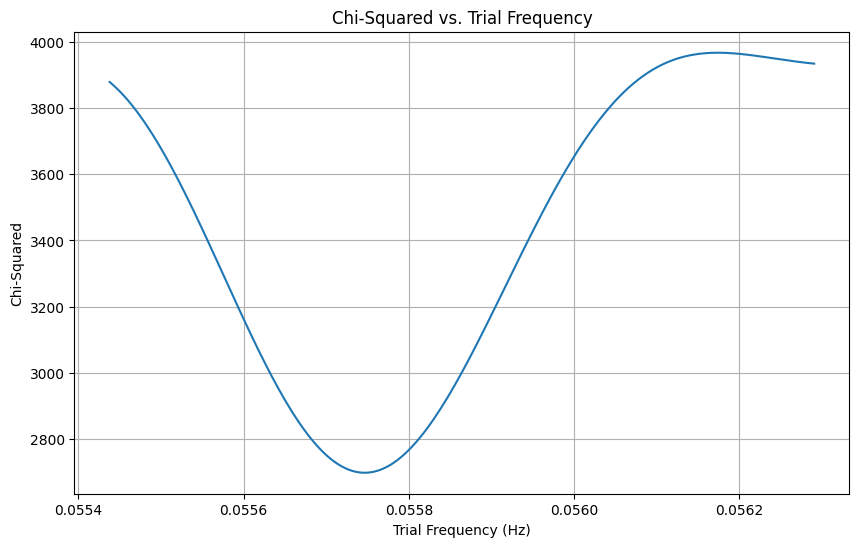

```python
# Generate dense trial frequencies
trial_frequencies = np.arange( best_frequency- Delta_f, best_frequency+Delta_f, Delta_f/100)# Arrays to store chi-squared values
best_frequency, best_fit_params, chi_squared_values,_ = find_best_frequency(t, residual_lightcurve, sigma, trial_frequencies, chi_squared)


# Plot chi-squared vs. frequency to locate QPO precise position
plt.figure(figsize=(10, 6))
plt.plot(trial_frequencies, chi_squared_values, linestyle='-')
plt.xlabel("Trial Frequency (Hz)")
plt.ylabel("Chi-Squared")
plt.title("Chi-Squared vs. Trial Frequency")
plt.grid(True)
plt.show()
```

As we zoom into the peak we can get a better estimate of the minimum chi sqaured and also begin to esitmate the uncertainty

|  | 0 | 1 | 2 | 3 |
| --- | --- | --- | --- | --- |
| Parameter | Best Frequency (Hz) | B | C | S |
| Value | 0.055747 | -3.998219 | 184.858053 | 57.08046 |

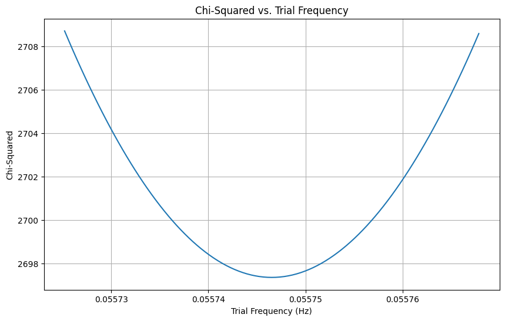

```python
from IPython.display import display

trial_frequencies = np.arange( best_frequency- Delta_f/20 , best_frequency + Delta_f/20, Delta_f/1000)# Arrays to store chi-squared values
best_frequency, best_fit_params, chi_squared_values, hessian_inv = find_best_frequency(t, residual_lightcurve, sigma, trial_frequencies, chi_squared)

dicto = {
    'Parameter': ['Best Frequency (Hz)', 'B', 'C', 'S'],
    'Value': [best_frequency, best_fit_params[0], best_fit_params[1], best_fit_params[2]]
}

df = pd.DataFrame(dicto)

display(df.T)

# Plot chi-squared vs. frequency to locate QPOs
plt.figure(figsize=(10, 6))
plt.plot(trial_frequencies, chi_squared_values, linestyle='-')
plt.xlabel("Trial Frequency (Hz)")
plt.ylabel("Chi-Squared")
plt.title("Chi-Squared vs. Trial Frequency")
plt.grid(True)
plt.show()
```

$\large \text{Derive and calculate the Period and Period Uncertainty } $

#### Finding Uncertainty in the Period from the Frequency

After identifying the peak frequency, we can determine the uncertainty in the period by finding the frequencies where $ \chi^2_{\text{min}} + 1 $ is crossed.

##### Period - Frequency Relation:

The relationship between the period $ P $ and frequency $ f $ is given by:

$ P = \frac{1}{f} $

##### Uncertainty Relation Calculation:

To calculate the uncertainty in the period $ \Delta P $:

$ \Delta P = \left| \frac{dP}{df} \right| \Delta f $

##### Derivative of Period with respect to Frequency:

The derivative of the period with respect to frequency is:

$ \frac{dP}{df} = -\frac{1}{f^2} $

##### Final Uncertainty in the Period:

Therefore, the uncertainty in the period $ \Delta P $ is:

$ \Delta P = \frac{\Delta f}{f^2} $

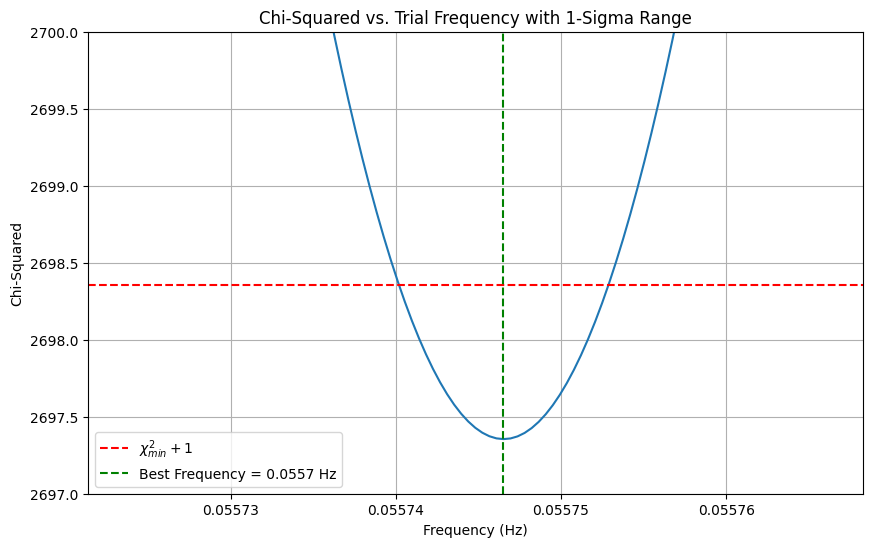

```
Frequency: 0.055747 Hz
1-Sigma Uncertainty in f: ±0.000006 Hz
Estimated Period P: 17.93834 s
1-Sigma Uncertainty in P: ±0.00192 s
```

```python
def calculate_period(chi_squared_values, trial_frequencies,frequency):
    """
    Calculate the period and the associated uncertainty from the chi-squared values.

    Parameters:
    - chi_squared_values: An array of chi-squared values corresponding to the trial frequencies.
    - trial_frequencies: Array of trial frequencies.
    - best_frequency: The best-fit frequency identified.

    Returns:
    - P_best: The period corresponding to the best frequency.
    - delta_P: The uncertainty in the period.
    """
    P = 1 / frequency
    chi_squared_1sigma = min(chi_squared_values) + 1
    crossing_indices = np.where(chi_squared_values <= chi_squared_1sigma)[0]
    f1 = trial_frequencies[crossing_indices[0]]
    f2 = trial_frequencies[crossing_indices[-1]]

    # Calculate the uncertainty in frequency and in the period
    delta_f = (f2 - f1) / 2
    delta_P = delta_f / frequency**2
    return P, delta_P, delta_f,chi_squared_1sigma


P_best, delta_P, delta_f,chi_squared_1sigma = calculate_period(chi_squared_values, trial_frequencies,best_frequency)

# Plot chi-squared vs frequency with 1-sigma range marked
plt.figure(figsize=(10, 6))
plt.plot(trial_frequencies, chi_squared_values, linestyle='-')
plt.axhline(chi_squared_1sigma, color='r', linestyle='--', label=r'$\chi^2_{min} + 1$')
plt.axvline(best_frequency, color='g', linestyle='--', label=f'Best Frequency = {best_frequency:.4f} Hz')
plt.xlabel("Frequency (Hz)")
plt.ylabel("Chi-Squared")
plt.ylim(2697,2700)
plt.title("Chi-Squared vs. Trial Frequency with 1-Sigma Range")
plt.legend()
plt.grid(True)
plt.show()


print(f"Frequency: {best_frequency:7f} Hz")
print(f"1-Sigma Uncertainty in f: ±{delta_f:7f} Hz")
print(f"Estimated Period P: {P_best:.5f} s")
print(f"1-Sigma Uncertainty in P: ±{delta_P:.5f} s")
```

As can we seen above we have found the minimum $\chi^2$ which correpsonds to the te best fit frequency and also the $\chi^2_{min} + 1$ intercepts

$\large \text{Derive and calculate the Amplitude and Amplitude Uncertainty } $

We are also interested in finding the amplitude of the QPO signal.

In order to get the uncertainty in the amplitude, we must use the inverse Hessian matrix found during our minimization process, as we need to propagate the errors in $C$ and $S$. These are not orthogonal, and hence the uncertainty is given by:

$$ \Delta A = \sum_{i,j} \left( \frac{\partial p_i}{\partial A} \right) \left( \frac{\partial p_j}{\partial A} \right) \text{Cov}(p_i, p_j) $$

##### Computed derivatives are:

$$ \frac{\partial A}{\partial S} = \frac{S}{A} \quad \quad \quad \frac{\partial A}{\partial C} = \frac{C}{A} $$

```python
A = np.sqrt(best_fit_params[1]**2 + best_fit_params[2]**2)

# Partial derivatives of A with respect to S and C
dA_dS = best_fit_params[1] / A  # dA/dS = S / sqrt(S^2 + C^2)
dA_dC = best_fit_params[2] / A  # dA/dC = C / sqrt(S^2 + C^2)


delta_A = np.sqrt(
    dA_dS**2 * hessian_inv[1, 1] + 2 * dA_dS * dA_dC * hessian_inv[1, 2] + dA_dC**2 * hessian_inv[2, 2]
)
print(f"Estimated Amplitude: {A:.5f} flux units")
print(f"1-Sigma Uncertainty in A: ±{delta_A:.5f} flux units")
## To find as percentage of out of eclipse flux compare to it, using before and after flux
flux = (sum(lightcurve[:220]) + sum(lightcurve[305:]))/(len(lightcurve[:220]) + len(lightcurve[305:]))
print(f"Estimated Amplitude: {A/flux:.7f} as a percentage of out-of-eclipse light")
print(f"1-Sigma Uncertainty in A: ±{delta_A/flux:.7f}")
```

```
Estimated Amplitude: 193.47007 flux units
1-Sigma Uncertainty in A: ±3.56540 flux units
Estimated Amplitude: 0.0160027 as a percentage of out-of-eclipse light
1-Sigma Uncertainty in A: ±0.0002949
```

$\large \text{Use IOS(Iterative Optimal Scaling) to fit and remove identified QPO's from the light curve} $

In order to find other QPOs more effectively, we will whiten the data to remove the already found QPO. Due to the nature of QPO's this will likely not entirely remove the peak as the model does not entirely fit the data. To do this we will subtract from the data the frequencies of peak already. Due to the nature of the data sometimes peaks will not be exactly removed we shall iteratvely run this process to identify many QPOs.

In order to eliminate peaks we will add them to the model of the data then perform iterative optimal scaling to whiten the data. We can then again find the minimum chi-sqaured of the distribution in order to find the other QPO's.

Whitening the data is achieved by subtracting from the data the modelled peak previously found. This allows us to continually find new peaks.

```python
def iterative_optimal_scaling(lightcurve, t, sigma, frequency, tolerance=1e-8, max_iterations=100):
    """
    Perform Iterative Optimal Scaling (IOS) to find the dominant frequency components and return the whitened light curve.

    Parameters:
    - residual_lightcurve: The light curve to be fitted and whitened.
    - t: The time array corresponding to the light curve.
    - sigma: The uncertainties in the data points (same length as the light curve).
    - frequency: The best-fit frequency for the signal.
    - tolerance: The convergence tolerance for the iterative process.
    - max_iterations: The maximum number of iterations.

    Returns:
    - whitened_curve: The whitened light curve (after removing the dominant frequency).
    """

    s = np.sin(2 * np.pi * frequency * t)
    c = np.cos(2 * np.pi * frequency * t)
    S_hat, C_hat, X_hat_0 = 0.0, 0.0, np.mean(residual_lightcurve)
    A_squared = 0.0

    for iteration in range(max_iterations):
        new_S_hat = np.sum((lightcurve - X_hat_0 - C_hat * c) * s / sigma**2) / np.sum(s**2 / sigma**2)
        new_C_hat = np.sum((lightcurve - X_hat_0 - S_hat * s) * c / sigma**2) / np.sum(c**2 / sigma**2)
        new_X_hat_0 = np.sum((lightcurve - S_hat * s - C_hat * c) / sigma**2) / np.sum(1 / sigma**2)

        new_A_squared = new_S_hat**2 + new_C_hat**2

        if abs(new_S_hat - S_hat) < tolerance and abs(new_C_hat - C_hat) < tolerance:
            break

        S_hat, C_hat, X_hat_0 = new_S_hat, new_C_hat, new_X_hat_0
        A_squared = new_A_squared

    dominant_component = X_hat_0 + S_hat * s + C_hat * c
    whitened_curve = lightcurve - dominant_component

    return whitened_curve
```

```python
QPOs = []
f1_whitened_curve = residual_lightcurve.copy()
frequency = best_frequency
f1_whitened_curve = iterative_optimal_scaling(f1_whitened_curve, t, sigma, frequency)
trial_frequencies = np.arange(0.0, nyquist_freq, Delta_f)
frequency, best_fit_params, chi_squared_values, _ = find_best_frequency(t, f1_whitened_curve, sigma, trial_frequencies, chi_squared)
trial_frequencies = np.arange(frequency- Delta_f/2 , frequency + Delta_f/2, Delta_f/100)
frequency, best_fit_params, chi_squared_values, _ = find_best_frequency(t, f1_whitened_curve, sigma, trial_frequencies, chi_squared)
trial_frequencies = np.arange(frequency- Delta_f/20, frequency+Delta_f/20, Delta_f/1000)
frequency, best_fit_params, chi_squared_values, inv_hessian = find_best_frequency(t, f1_whitened_curve, sigma, trial_frequencies, chi_squared)
P_best, delta_P, delta_f, _ = calculate_period(chi_squared_values, trial_frequencies,frequency)
A = np.sqrt(best_fit_params[1]**2 + best_fit_params[2]**2)
dA_dS = best_fit_params[1] / A
dA_dC = best_fit_params[2] / A
delta_A = np.sqrt(
    dA_dS**2 * hessian_inv[1, 1] + 2 * dA_dS * dA_dC * hessian_inv[1, 2] + dA_dC**2 * hessian_inv[2, 2]
)
QPOs.append([frequency,delta_f,P_best, delta_P,A,delta_A])
```

```python
for i in range(5):
    f1_whitened_curve = iterative_optimal_scaling(f1_whitened_curve, t, sigma, frequency)
    trial_frequencies = np.arange(0.0, nyquist_freq, Delta_f)
    frequency, best_fit_params, chi_squared_values,_ = find_best_frequency(t, f1_whitened_curve, sigma, trial_frequencies, chi_squared)
    trial_frequencies = np.arange(frequency- Delta_f/2 , frequency + Delta_f/2, Delta_f/100)
    frequency, best_fit_params, chi_squared_values,_ = find_best_frequency(t, f1_whitened_curve, sigma, trial_frequencies, chi_squared)
    trial_frequencies = np.arange(frequency- Delta_f/20, frequency+Delta_f/20, Delta_f/1000)
    frequency, best_fit_params, chi_squared_values,inv_hessian = find_best_frequency(t, f1_whitened_curve, sigma, trial_frequencies, chi_squared)
    P_best, delta_P, delta_f,_ = calculate_period(chi_squared_values, trial_frequencies,frequency)
    A = np.sqrt(best_fit_params[1]**2 + best_fit_params[2]**2)
    dA_dS = best_fit_params[1] / A
    dA_dC = best_fit_params[2] / A
    delta_A = np.sqrt(
        dA_dS**2 * hessian_inv[1, 1] + 2 * dA_dS * dA_dC * hessian_inv[1, 2] + dA_dC**2 * hessian_inv[2, 2]
    )

    QPOs.append([frequency,delta_f,P_best, delta_P,A,delta_A])
```

$\large \text{A table showing other possible QPO's identified after using IOS. } $

```python
table = {
    "Frequency Hz": [entry[0] for entry in QPOs],
    "Frequency Uncertainty (delta_f)": [entry[1] for entry in QPOs],
    "Period s(P_best)": [entry[2] for entry in QPOs],
    "Period Uncertainty (delta_P)": [entry[3] for entry in QPOs],
    "Amplitude flux units":[entry[4] for entry in QPOs],
    "Amplitude Uncertainty (delta_A)":[entry[5] for entry in QPOs]
}

# Create DataFrame
df = pd.DataFrame(table)
df.head(6)
```

|  | Frequency Hz | Frequency Uncertainty (delta_f) | Period s(P_best) | Period Uncertainty (delta_P) | Amplitude flux units | Amplitude Uncertainty (delta_A) |
| --- | --- | --- | --- | --- | --- | --- |
| 0 | 0.055121 | 0.000009 | 18.141931 | 0.003088 | 165.356721 | 3.430462 |
| 1 | 0.055709 | 0.000021 | 17.950287 | 0.006870 | 56.628330 | 3.409874 |
| 2 | 0.054458 | 0.000021 | 18.362842 | 0.007190 | 52.433522 | 3.401800 |
| 3 | 0.069110 | 0.000021 | 14.469685 | 0.004464 | 41.671108 | 3.807419 |
| 4 | 0.068524 | 0.000020 | 14.593412 | 0.004359 | 57.958383 | 3.365923 |
| 5 | 0.067275 | 0.000021 | 14.864454 | 0.004711 | 43.018657 | 4.032705 |

$\large \text{A plot showing the Power spectrum of different frequencies as a function of time} $

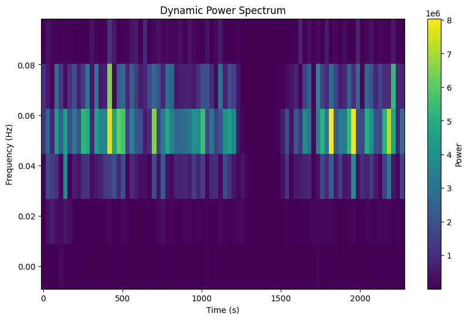

```python
from scipy.signal import welch, find_peaks

segment_length = 10
overlap = 0.5
sample_freq = 1 / delta_t

n_segments = int(len(residual_lightcurve) / (segment_length * (1 - overlap)))
frequencies = None
power_spectrum = []

for i in range(n_segments):
    start = int(i * segment_length * (1 - overlap))
    end = start + segment_length
    if end > len(residual_lightcurve):
        break

    freqs, power = welch(residual_lightcurve[start:end], fs=sample_freq, nperseg=segment_length)
    power_spectrum.append(power)
    if frequencies is None:
        frequencies = freqs

power_spectrum = np.array(power_spectrum)

# Dynamic Power Spectrum Plot
plt.figure(figsize=(10, 6))
plt.pcolormesh(np.arange(len(power_spectrum)) * (segment_length * (1 - overlap)) * delta_t, frequencies, power_spectrum.T, shading='auto')
plt.colorbar(label='Power')
plt.xlabel('Time (s)')
plt.ylabel('Frequency (Hz)')
plt.title('Dynamic Power Spectrum')
plt.show()
```

$\large \text{A plot of the amplitude of the strongest QPO as a function of time. } $

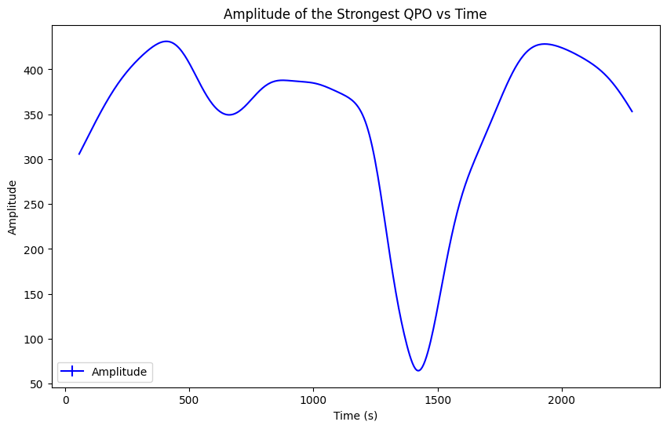

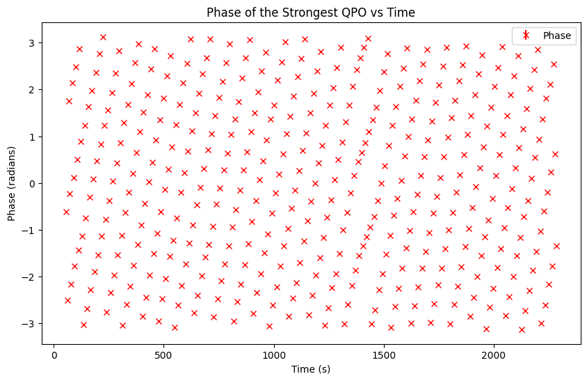

```python
frequency = best_frequency
tolerance = 1e-10
max_iterations = 1000000


amplitude = []
phase = []
amplitude_errors = []
phase_errors = []

for time in t[10:-10]:


    w = np.exp(-(t - time)**2 / (2 * sigma**2))
    s = np.sin(2 * np.pi * frequency * (t - time))
    c = np.cos(2 * np.pi * frequency * (t - time))

    S_hat = 0.0
    C_hat = 0.0
    X_hat_0 = np.mean(residual_lightcurve)
    A_squared = 0.0

    for iteration in range(max_iterations):
        new_S_hat = np.sum((residual_lightcurve - X_hat_0 - C_hat * c) * s * w) / np.sum(s**2 * w)
        new_C_hat = np.sum((residual_lightcurve - X_hat_0 - S_hat * s) * c * w) / np.sum(c**2 * w)
        new_X_hat_0 = np.sum((residual_lightcurve - S_hat * s - C_hat * c) * w) / np.sum(w)
        new_A_squared = new_S_hat**2 + new_C_hat**2


        if abs(new_S_hat - S_hat) < tolerance and abs(new_C_hat - C_hat) < tolerance:
            break


        S_hat = new_S_hat
        C_hat = new_C_hat
        X_hat_0 = new_X_hat_0
        A_squared = new_A_squared

    A_value = np.sqrt(A_squared)
    amplitude.append(A_value)

    phase_value = np.arctan2(S_hat, C_hat)
    phase.append(phase_value)

    delta_S_hat = np.abs(new_S_hat - S_hat)
    delta_C_hat = np.abs(new_C_hat - C_hat)

    # Amplitude uncertainty Assume orthogonal parameters
    if A_value > 0:
        A_error = np.sqrt((S_hat / A_value * delta_S_hat)**2 + (C_hat / A_value * delta_C_hat)**2)
    else:
        A_error = 0

    # Phase uncertainty (using similar error propagation for arctan)
    if np.cos(phase_value) != 0:
        phase_error = np.sqrt((delta_S_hat / C_hat)**2 + (delta_C_hat / S_hat)**2)
    else:
        phase_error = 0

    amplitude_errors.append(A_error)
    phase_errors.append(phase_error)


amplitude = np.array(amplitude)
phase = np.array(phase)
amplitude_errors = np.array(amplitude_errors)
phase_errors = np.array(phase_errors)

# Amplitude vs Time with error bars
plt.figure(figsize=(10, 6))
plt.errorbar(t[10:-10], amplitude, yerr=amplitude_errors, color='b', label='Amplitude')
plt.xlabel('Time (s)')
plt.ylabel('Amplitude')
plt.title('Amplitude of the Strongest QPO vs Time')
plt.legend()
plt.show()

# Phase vs Time with error bars
plt.figure(figsize=(10, 6))
plt.errorbar(t[10:-10], phase,fmt='x', yerr=phase_errors, color='r', label='Phase')
plt.xlabel('Time (s)')
plt.ylabel('Phase (radians)')
plt.title('Phase of the Strongest QPO vs Time')
plt.legend()
plt.show()
```

Disclaimer: I'm fairly unconfident in my plot of the amplitude of the strongest QPO with respect to time despite trying varying techniques to whiten or more clearly find the the QPO's amplitude it seems to be oscillating a lot more than it should be. This is likely due to it fitting the residua containing many different QPO's but i was unable to find a satisfying way to eliminate this problem.

Regardless, The amplitude of the QPO clearly decreases significantly during the eclipse, this suggests the QPO is associated with the inner accretion disk. The accretion disk will be obscured during the eclipse and therefore the amplitude of the QPO's will decrease. I conclude the QPO is due to the accretion disk as the amplitde does not decrease entirely to zeor and and a phase shift occurs incdicating that some of the light emittted by the disk is still present.